# TATA Variants

Jeremy Primus and Kevin Morey

2/8/2018

## Introduction

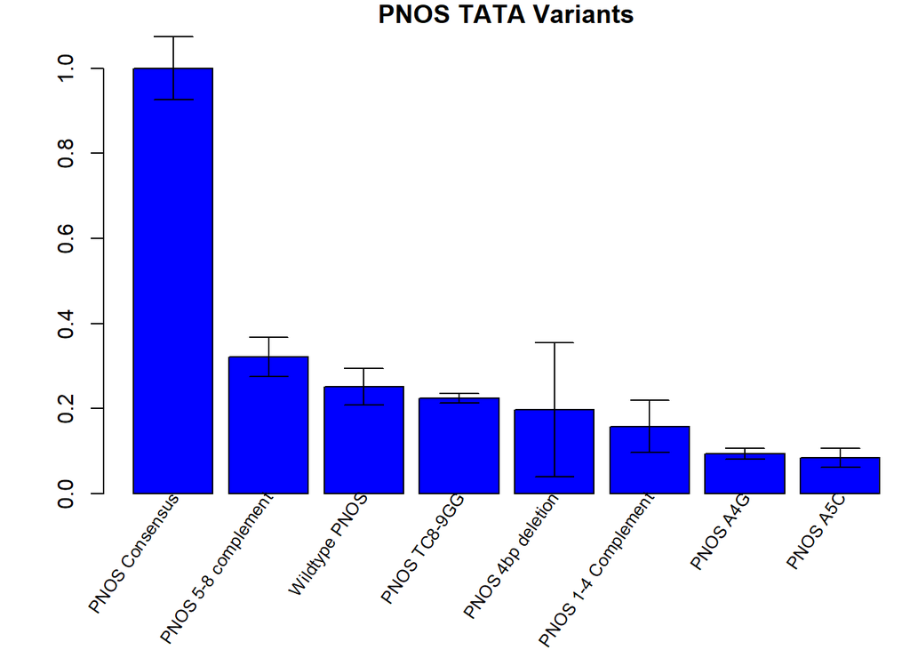

## Analysis

Assuming the measured luminescence is proportional to the transcription rate, we can approximate the effect of the nucleotide edits on the equilibrium binding constant, $K_{eq}$

## Thermodynamically Modeling Transcription Rates

Define all energies relative to a ground state: $\Delta G$  
The TATA binding protein/promoter interaction has two possible states: unbound, and bound  
The unbound state is the same energetically for all promoter variants, so we choose this to be the ground state: 0

For the *i*-th variant, the binding interaction energy, measured relative to the unoccupied state, 0 is $\Delta G_{i}$

The partition function describes the statistical properties of a system in thermodynamic equilibrium.

$$P(b) = \frac{e^{-\Delta G_{i}}}{1+e^{-\Delta G_{i}}}$$
Assuming transcription rate $TR_i$ is proportional to binding probability
$$TR_{i} = \alpha \frac{e^{-\Delta G_{i}}}{1+e^{-\Delta G_{i}}} + \epsilon$$
where $\alpha$ and $\epsilon$ are the theoretical maximum and minumum transcription rates
Assume measured luminescence to be proportional to $TR_{i}$
so
$$L_i = A\left [\alpha \frac{e^{-\Delta G_{i}}}{1+e^{-\Delta G_{i}}} + \epsilon \right] = \widetilde{\alpha} \frac{e^{-\Delta G_{i}}}{1+e^{-\Delta G_{i}}} + \widetilde{\epsilon}$$

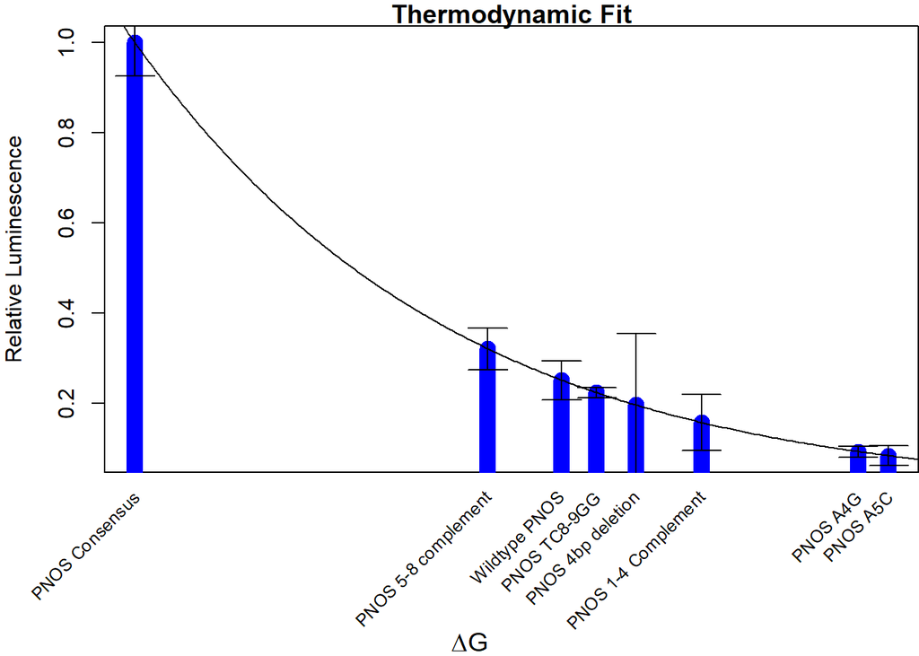

**Table 1.** Binding energy values ($E/k_{B}T$) obtained from thermodynamic fits. Values are relative to consensus.

[output not shown]